# RNA-seq Data Analysis

## 1 The Data

This exercise uses RNA-seq data from [FU et al. 2015, *Nature Cell Biology*](https://www.nature.com/articles/ncb3117). The data compares gene expression in luminal cells of pregnant versus lactating mice. You can download the data from [this Galaxy tutorial](https://training.galaxyproject.org/training-material/topics/transcriptomics/tutorials/rna-seq-viz-with-heatmap2/tutorial.html).

The dataset consists of three CSV files:

1. `heatmap_genes.csv`: A list of interesting genes to analyze (used in Figure 6b of the paper)
2. `DE_results.csv`: Differential expression results, including logFC, AveExpr, t-statistic, and p-value for all genes
3. `normalized_counts.csv`: Normalized counts for genes across different samples

## 2 Questions

#### What are the top 20 most significantly differentially expressed genes?

- Tip: Filter the genes based on p-value and log fold change, then order by p-value.

#### Create a heatmap of the top 20 most significant genes. How do the expression patterns differ between pregnant and lactating samples?

- Checkout the `pheatmap` package for creating heatmaps.

#### Create a volcano plot to visualize the differential expression results. How many genes are significantly up-regulated or down-regulated?

- First create a simple volcano plot
- Then you can try to label the 10 most significant genes in the volcano plot
- Check my R script and/or [this tutorial](https://erikaduan.github.io/posts/2021-01-02-volcano-plots-with-ggplot2/) on how to create a volcano plot with ggplot

#### Perform a Principal Component Analysis (PCA) on the top 20 significant genes. What can you conclude about the separation of pregnant and lactating samples?

- Tip: Use `prcomp()` for PCA and `factoextra::fviz_pca_ind()` for visualization.

## 3 Useful Functions

To complete these tasks, you may find the following R functions and packages helpful:

1. Data manipulation:
   - `janitor::clean_names()`: Clean column names
   - `left_join()`: Combine data frames
2. Statistical analysis:
   - `scale()`: Scale numeric variables
   - `prcomp()`: Perform Principal Component Analysis
3. Visualization:
   - `pheatmap::pheatmap()`: Create heatmaps (needs a matrix, so you need to reshape your data first into a matrix)
   - `ggrepel::geom_text_repel()`: Add non-overlapping labels to plots
   - `factoextra::fviz_pca_ind()`: Visualize PCA results
4. Other useful functions:
   - `as.matrix()`: Convert data frames to matrices
   - `drop_na()`: Drop rows with missing values (maybe needed for PCA because it doesn’t handle missing values)

## 4 Example analysis

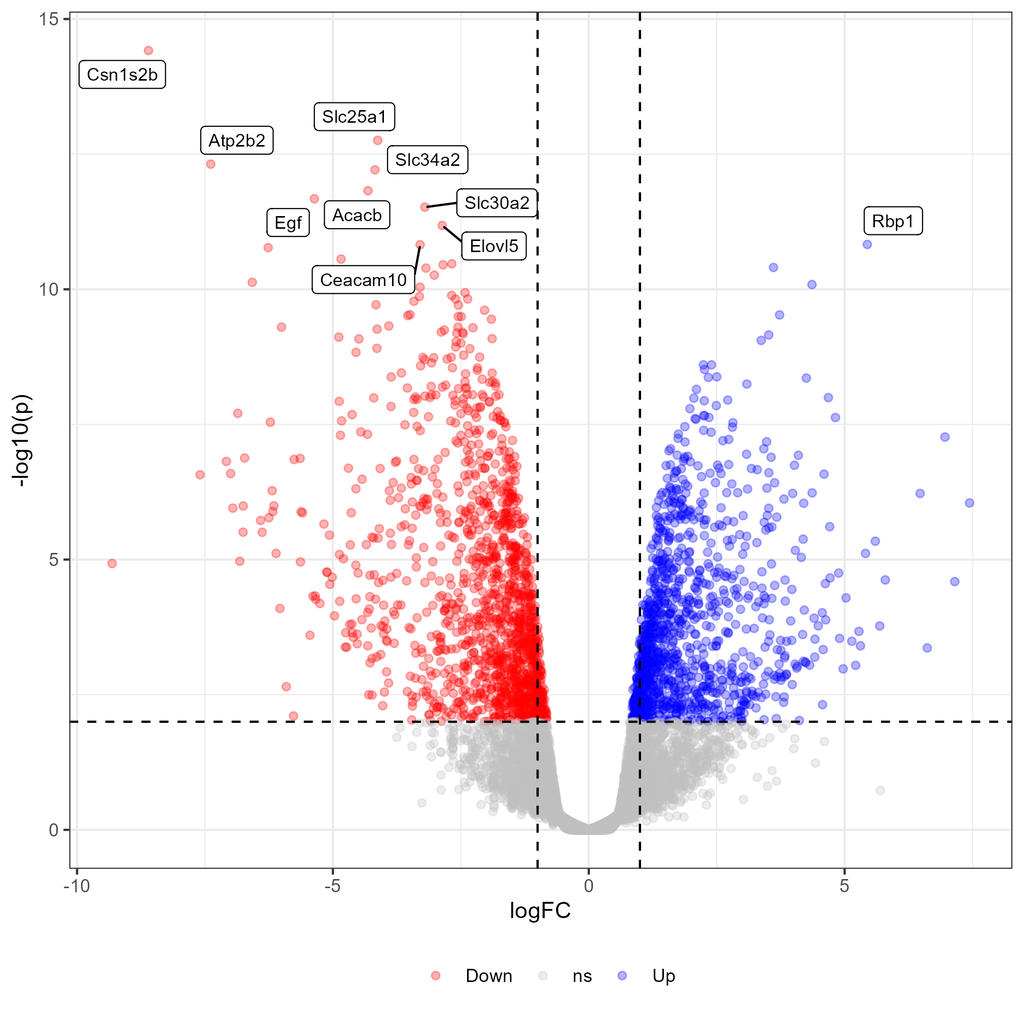

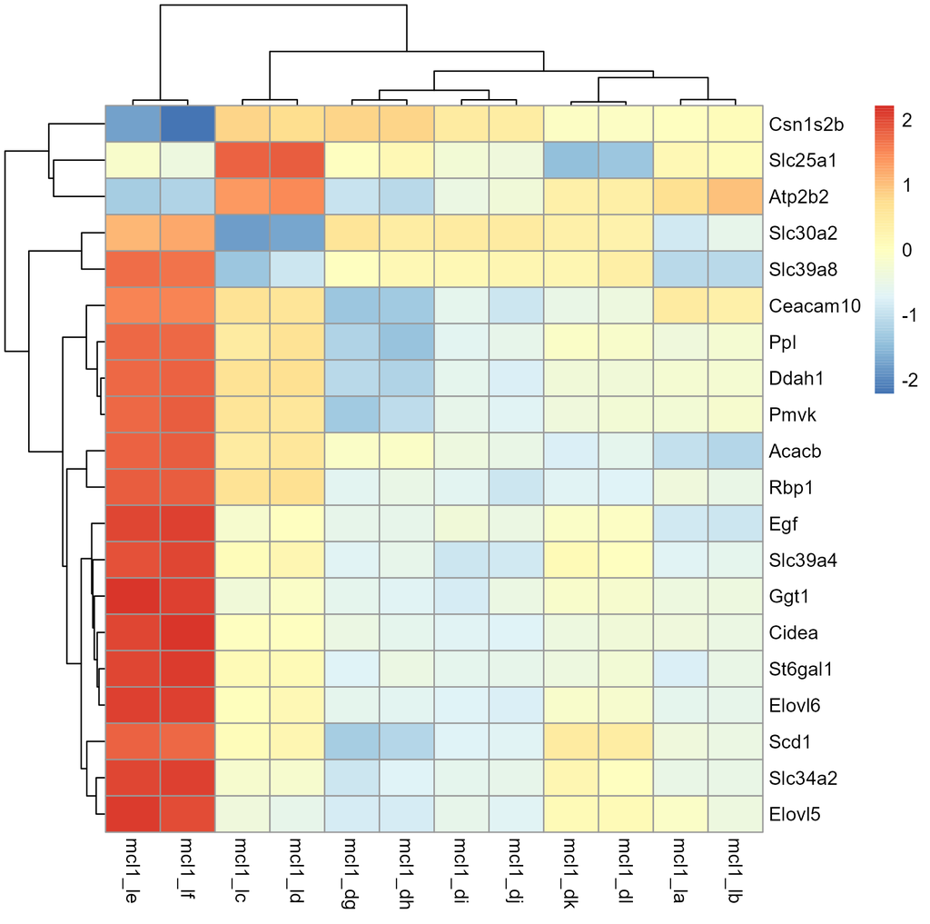